# Singapore’s Demographic Composition Across Time Dataviz Makeover Exercise #8

[Denise Adele Chua](http://www.linkedin.com/in/deniseadelechua/) [View my tableau public account](http://public.tableau.com/profile/denise.chua#!/)

3/10/2020

# 1.0 Introduction

Ever wondered which region of Singapore is more popular with the working population, Or where there is a higher concentration of aged population, and how has this age demographics concentration changed over time? This makeover exercise aims to reveal the changing patterns of demographic composition in Singapore by geographical hierarchy over time. The visualisation explores several dimensions, including:

- Population of 3 broad age groups: The Young (age 0-24yrs), Working-age (25-64yrs) and Aged (above 65years)
- Planning Area and Region
- Time period of 2011-2019, in years

# 2.0 Data & Design

## 2.1 Challenges

1. The dataset contains administrative boundaries demarcated by the Urban Authority of Singapore, such as Planning Area and Subzone. However, the high level demarcation of region (i.e. North, North-east, East, West, Central) is not found in this dataset. The challenge is therefore in obtaining the data on which planning areas are organised under which regions, and then mapping this information onto the dataset.
2. The visualisation aims to reveal changing patterns in age compositions across geographical demarcations and hierarchies. As there are many planning areas in Singapore, the challenge is then in being able to produce a clean graph that is able to clearly show trends of age compositions of each region/planning area and at the same time effectively compare the trends of one region/planning area with that of others.
3. To simultaneously visualise 3 measures, namely the population proportion of the Young, Working Age and Aged broad age categories. On top of which, the requirement for this exercise is to use static plots to create the visualisation, which restricts revealing details or dimensions through animation or interactivity.

## 2.2 Ways to Overcome Challenges

1. This census division information data can be found on Wikipedia page. Link:https://en.wikipedia.org/wiki/Planning_Areas_of_Singapore The table listing the regions and its corresponding planning areas can be scraped using **Rvest** package.
2. The use slope graph can help to put focus on the changes in dependency ratios across sequential points in time, as visually encoded by the gradient of the slopes. It is not concerned with the variations in between the selected time intervals, hence helps to reduce the complexity of the visualisation. At the same time, slope graphs can effectively show how each region’s rate of change compares with other regions. The vertical order of the regions also reveal the ranking of regions in terms of dependency ratios at each point in time.
3. Ternary bubble plot can be used to simultaneously visualise the 3 ratios using uses a barycentric coordinate system. To show changes across time, trellis of ternary graphs (aka faceting) can be created. Alternatively, a ternary plot that connects the data points in sequential years can be created.

## 2.3 Sketch of Proposed Design

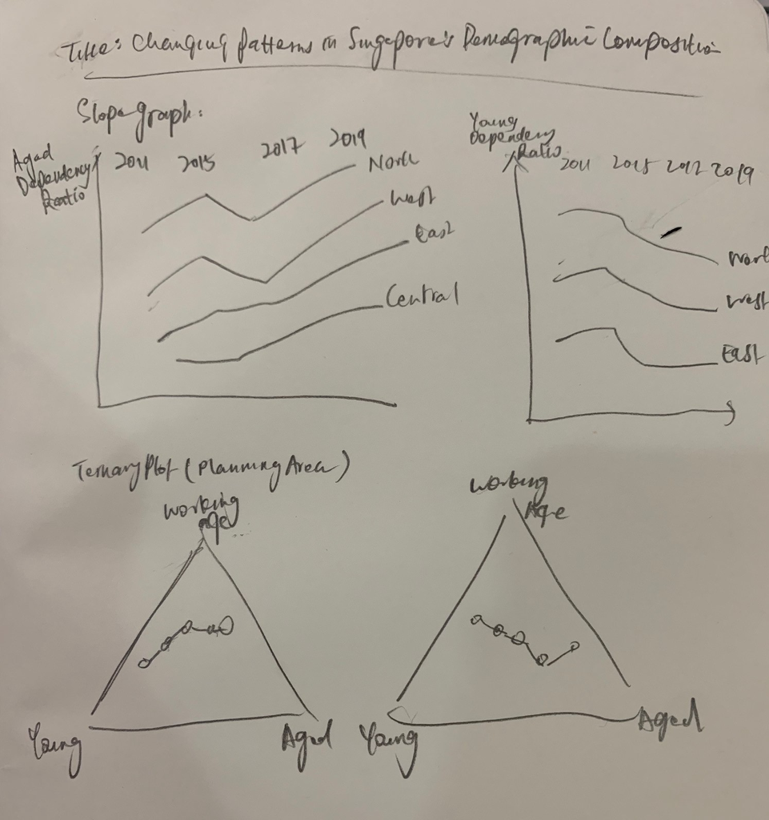

# 3.0 Step-by-step Data Visualisation Preparation

## 3.1 Installing and launching R packages

A list of packages, namely **tidyverse**, **rvest**, **ggtern**, **CGPfunctions**, **ggpubr**, **viridis** are required for this makeover exercise. This code chunk installs the required packages and loads them onto RStudio environment.

```r
packages <- c('tidyverse','rvest','reshape2','ggtern','viridis','ggrepel','CGPfunctions','ggpubr')

for (p in packages){
  if (!require(p,character.only=T)){
    install.packages(p)
  }
  library(p, character.only=T)
}
```

## 3.2 Data Preparation

### Data Source

The dataset used in this exercise is **Singapore Residents by Planning AreaSubzone, Age Group, Sex and Type of Dwelling, June 2011-2019.csv**, published by the Singapore Department of Statistics and was downloaded from the website https://www.singstat.gov.sg/find-data/search-by-theme/population/geographic-distribution/latest-data.

### Importing the dataset

Data import was accomplished using `read_csv()` of **readr** package, which is useful for reading delimited files into a `tibble`.

```r
# Reading the csv file as a tbl_df
pop_data <- read_csv("Data/respopagesextod2011to2019.csv")
# Inspecting the structure of the dataset
str(pop_data)
```

```
## Classes 'spec_tbl_df', 'tbl_df', 'tbl' and 'data.frame': 883728 obs. of  7 variables:
##  $ PA  : chr  "Ang Mo Kio" "Ang Mo Kio" "Ang Mo Kio" "Ang Mo Kio" ...
##  $ SZ  : chr  "Ang Mo Kio Town Centre" "Ang Mo Kio Town Centre" "Ang Mo Kio Town Centre" "Ang Mo Kio Town Centre" ...
##  $ AG  : chr  "0_to_4" "0_to_4" "0_to_4" "0_to_4" ...
##  $ Sex : chr  "Males" "Males" "Males" "Males" ...
##  $ TOD : chr  "HDB 1- and 2-Room Flats" "HDB 3-Room Flats" "HDB 4-Room Flats" "HDB 5-Room and Executive Flats" ...
##  $ Pop : num  0 10 30 50 0 0 40 0 0 10 ...
##  $ Time: num  2011 2011 2011 2011 2011 ...
##  - attr(*, "spec")=
##   .. cols(
##   ..   PA = col_character(),
##   ..   SZ = col_character(),
##   ..   AG = col_character(),
##   ..   Sex = col_character(),
##   ..   TOD = col_character(),
##   ..   Pop = col_double(),
##   ..   Time = col_double()
##   .. )
```

The columns were renamed more intuitively from ‘PA’, ‘SZ’, ‘AG’, ‘Pop’, and ‘Time’ to ‘Planning Area’, ‘Subzone’, ‘Age Group’, ‘Population’ and ‘Year’, respectively.

```r
pop_data <- pop_data %>%
  rename('Planning_Area'='PA',
         'Subzone'='SZ',
         'Age_Group'='AG',
         'Population'='Pop',
         'Year'='Time')

# verify if the columns have been renamed correctly
colnames(pop_data)
```

```
## [1] "Planning_Area" "Subzone"       "Age_Group"     "Sex"
## [5] "TOD"           "Population"    "Year"
```

### Scraping Planning Region Data from Wikipedia

The dataset contains administrative boundaries demarcated by the Urban Authority of Singapore, such as Planning Area and Subzone. However, the high level demarcation of region (i.e. North, North-east, East, West, Central) is not found in this dataset, hence, will be supplemented through web scraping from external sources. **Rvest** package is used for the purpose of web scraping.

```r
#Specifying the url for website to be scraped
url <- 'https://en.wikipedia.org/wiki/Planning_Areas_of_Singapore'

#Scraping HTML table
planning_region <- url %>%
  read_html() %>%
  html_nodes(xpath='//*[@id="mw-content-text"]/div/table[3]') %>%
  html_table(fill=TRUE)

planning_region <- planning_region[[1]]

head(planning_region)
```

```
##   Name (English) Malay                          Chinese        Pinyin
## 1     Ang Mo Kio               宏茂桥 Hóng mào qiáo
## 2          Bedok     *                 勿洛        Wù luò
## 3         Bishan                       碧山       Bì shan
## 4       Boon Lay                       文礼        Wén li
## 5    Bukit Batok     * 武吉巴督    Wují ba du
## 6    Bukit Merah     *                 红山     Hóng shan
##                                                                                                                               Tamil
## 1                                                        ஆங் மோ கியோ
## 2                                                                                  பிடோக்
## 3                                                                                  பீஷான்
## 4                                                                                 பூன் லே
## 5 புக்கிட் பாத்தோக்
## 6                                 புக்கிட் மேரா
##       Region Area (km2) Population[7] Density (/km2)
## 1 North-East      13.94       163,950         13,400
## 2       East      21.69       279,380         13,000
## 3    Central       7.62        88,010         12,000
## 4       West       8.23            30            3.6
## 5       West      11.13       153,740         14,000
## 6    Central      14.34       151,980         11,000
```

```r
# dplyr for data wrangling
# renaming and selecting required columns
# write to csv
planning_region_final <- planning_region %>%
  tbl_df() %>%
  rename('Planning_Area'='Name (English)') %>%
  select(c('Planning_Area','Region'))

head(planning_region_final)
```

```
## # A tibble: 6 x 2
##   Planning_Area Region
##   <chr>         <chr>
## 1 Ang Mo Kio    North-East
## 2 Bedok         East
## 3 Bishan        Central
## 4 Boon Lay      West
## 5 Bukit Batok   West
## 6 Bukit Merah   Central
```

### Data Wrangling

The two datasets will be combined using a `left_join()` from the **dplyr** package.

```r
pop_data_final <- left_join(pop_data, planning_region_final, by="Planning_Area")

head(pop_data_final)
```

```
## # A tibble: 6 x 8
##   Planning_Area Subzone     Age_Group Sex   TOD          Population  Year Region
##   <chr>         <chr>       <chr>     <chr> <chr>             <dbl> <dbl> <chr>
## 1 Ang Mo Kio    Ang Mo Kio~ 0_to_4    Males HDB 1- and ~          0  2011 North~
## 2 Ang Mo Kio    Ang Mo Kio~ 0_to_4    Males HDB 3-Room ~         10  2011 North~
## 3 Ang Mo Kio    Ang Mo Kio~ 0_to_4    Males HDB 4-Room ~         30  2011 North~
## 4 Ang Mo Kio    Ang Mo Kio~ 0_to_4    Males HDB 5-Room ~         50  2011 North~
## 5 Ang Mo Kio    Ang Mo Kio~ 0_to_4    Males HUDC Flats ~          0  2011 North~
## 6 Ang Mo Kio    Ang Mo Kio~ 0_to_4    Males Landed Prop~          0  2011 North~
```

TOD (Type of Dwelling) will not be used in the visualisation, therefore it is necessary to aggregate the population measure excluding TOD level of detail. This can be achieved by using `group_by` and `summarise` functions from the **dplyr** package to sum up population by Year, Region, Planning_Area and Age_Group.

```r
agg_pop <- pop_data_final %>%
  select(c("Year","Region","Planning_Area","Age_Group","Population")) %>%
  group_by(Year,Region,Planning_Area,Age_Group) %>%
  summarise(Population=sum(Population))
head(agg_pop)
```

```
## # A tibble: 6 x 5
## # Groups:   Year, Region, Planning_Area [1]
##    Year Region  Planning_Area Age_Group Population
##   <dbl> <chr>   <chr>         <chr>          <dbl>
## 1  2011 Central Bishan        0_to_4          3740
## 2  2011 Central Bishan        10_to_14        5390
## 3  2011 Central Bishan        15_to_19        6850
## 4  2011 Central Bishan        20_to_24        6710
## 5  2011 Central Bishan        25_to_29        5740
## 6  2011 Central Bishan        30_to_34        5960
```

The absence of missing data is verified to ascertain that the data preparation thus far has been done correctly.

```r
apply(agg_pop, 2, function(x) any(is.na(x)))
```

```
##          Year        Region Planning_Area     Age_Group    Population
##         FALSE         FALSE         FALSE         FALSE         FALSE
```

## 3.3 Feature Engineering

The exhaustive list of age group categories is printed for verification.

```r
agg_pop$Age_Group <- as.factor(agg_pop$Age_Group)
levels(agg_pop$Age_Group)
```

```
##  [1] "0_to_4"      "10_to_14"    "15_to_19"    "20_to_24"    "25_to_29"
##  [6] "30_to_34"    "35_to_39"    "40_to_44"    "45_to_49"    "5_to_9"
## [11] "50_to_54"    "55_to_59"    "60_to_64"    "65_to_69"    "70_to_74"
## [16] "75_to_79"    "80_to_84"    "85_to_89"    "90_and_over"
```

Categorizing Age Group

```r
Young <- c("0_to_4","5_to_9","10_to_14","15_to_19","20_to_24")
Working_age <- c("25_to_29","30_to_34","35_to_39","40_to_44","45_to_49","50_to_54","55_to_59","60_to_64")
Aged <- c("65_to_69","70_to_74","75_to_79","80_to_84","85_to_89", "90_and_over")


agg_pop_ag <- agg_pop %>%
  mutate(AgeGroup = case_when(
    Age_Group %in% Young ~ "Young",
    Age_Group %in% Working_age ~ "Working_Age",
    Age_Group %in% Aged ~ "Aged")) %>%
  select(-Age_Group)

head(agg_pop_ag)
```

```
## # A tibble: 6 x 5
## # Groups:   Year, Region, Planning_Area [1]
##    Year Region  Planning_Area Population AgeGroup
##   <dbl> <chr>   <chr>              <dbl> <chr>
## 1  2011 Central Bishan              3740 Young
## 2  2011 Central Bishan              5390 Young
## 3  2011 Central Bishan              6850 Young
## 4  2011 Central Bishan              6710 Young
## 5  2011 Central Bishan              5740 Working_Age
## 6  2011 Central Bishan              5960 Working_Age
```

Deriving Young, Working Age and Aged population measures using `spread()` from **tidyr** package. By defining the AgeGroup as the key and the Population as the value, the function spreads the key-value pair across multiple columns.

Take note that an index column that uniquely identify each observation must be introduced here, to prevent `spread()` from collapsing observations with same values into a single row.

```r
spread_pop_intermediate <- agg_pop_ag %>%
  mutate(i = row_number()) %>%
  spread(AgeGroup, Population) %>%
  select(-i)
head(spread_pop_intermediate)
```

```
## # A tibble: 6 x 6
## # Groups:   Year, Region, Planning_Area [1]
##    Year Region  Planning_Area  Aged Working_Age Young
##   <dbl> <chr>   <chr>         <dbl>       <dbl> <dbl>
## 1  2011 Central Bishan           NA          NA  3740
## 2  2011 Central Bishan           NA          NA  5390
## 3  2011 Central Bishan           NA          NA  6850
## 4  2011 Central Bishan           NA          NA  6710
## 5  2011 Central Bishan           NA        5740    NA
## 6  2011 Central Bishan           NA        5960    NA
```

The resulting dataframe contains alot of NA values, due to the introduction of the index column prior to `spread()`. To resolve this, the NA values are first replaced with 0, and then `group_by` and `summarise()` are used sum up the observations for Aged, Working_Age and Young columns for a given year, region and planning area.

```r
spread_pop_intermediate[is.na(spread_pop_intermediate)] <- 0
spread_pop_ag <-spread_pop_intermediate %>%
  group_by(Year,Region,Planning_Area) %>%
  summarise(Aged=sum(Aged),Working_Age=sum(Working_Age),Young=sum(Young)) %>%
  mutate(Population= Aged + Working_Age + Young)
head(spread_pop_ag)
```

```
## # A tibble: 6 x 7
## # Groups:   Year, Region [1]
##    Year Region  Planning_Area  Aged Working_Age Young Population
##   <dbl> <chr>   <chr>         <dbl>       <dbl> <dbl>      <dbl>
## 1  2011 Central Bishan         9290       54480 27190      90960
## 2  2011 Central Bukit Merah   24280       95730 36970     156980
## 3  2011 Central Bukit Timah    8010       40500 22070      70580
## 4  2011 Central Downtown Core   560        2130   640       3330
## 5  2011 Central Geylang       14870       73000 32530     120400
## 6  2011 Central Kallang       14860       62950 24490     102300
```

Further data manipulations will be performed using spread_pop_ag as the base dataframe, as and when required to create the subsequent data visualisations.